# Lab 01

Rafael de Souza Guerra

8 de abril de 2019

Carregando dados:

```r
dados = read_csv("../data/series_from_imdb.csv.zip", col_types = "ccdcdcdddddddddddd")
```

## Pergunta 1

**Quais são as 5 séries mais bem avaliadas de modo geral, considerando todos os seus episódios?**

Considerando a média como medida de avaliação, é possível responder com a seguinte consulta:

```
## # A tibble: 5 x 2
##   series_name                          UserRating
##   <chr>                                     <dbl>
## 1 Yeh Meri Family                            9.26
## 2 Galera do Barulho                          9.15
## 3 Game of Thrones                            9.11
## 4 Caçadores de Sombras                       9.10
## 5 Cosmos: Uma Odisséia do Espaço-Tempo       9.08
```

Surpreendentemente, é possível verificar que Galera do barulho, com seu último episódio indo ao ar a mais de 20 anos, mantém uma média geral superior a de séries mais recentes e populares, como Game of Thrones e Caçadores de Sombras. Vale salientar que Cosmos e Yeh Meri Family, tiveram apenas uma temporada, sendo que a última tenha uma possível continuação.

**Obs.: no restante deste lab, iremos analisar estas 5 séries citadas.**

```r
top5 = dados %>% filter(series_name %in% c("Yeh Meri Family", "Galera do Barulho", "Game of Thrones", "Caçadores de Sombras", "Cosmos: Uma Odisséia do Espaço-Tempo"))
```

## Pergunta 2

**Dentre estas séries, como as avaliações se comportam no decorrer dos episódios? Existe alguma tendência?**

Para fins de organização e detalhes, essa pergunta será respondida por meio de vários graficos:

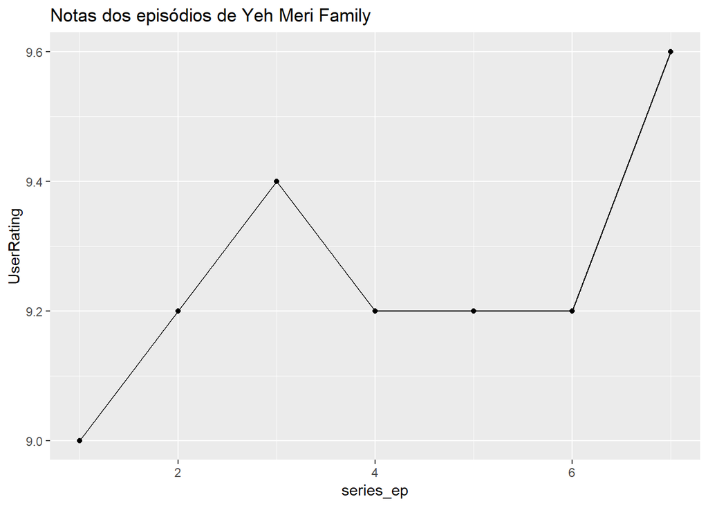

```r
top5 %>% filter(series_name == "Yeh Meri Family") %>% ggplot() + geom_line(mapping = aes(x = series_ep, y = UserRating)) + geom_point(mapping = aes(x = series_ep, y = UserRating)) + labs(title = "Notas dos episódios de Yeh Meri Family")
```

Aqui podemos observar que a série, no geral, se manteve num crescimento relativamente estável, com o último episódio obtendo notas maiores que o primeiro.

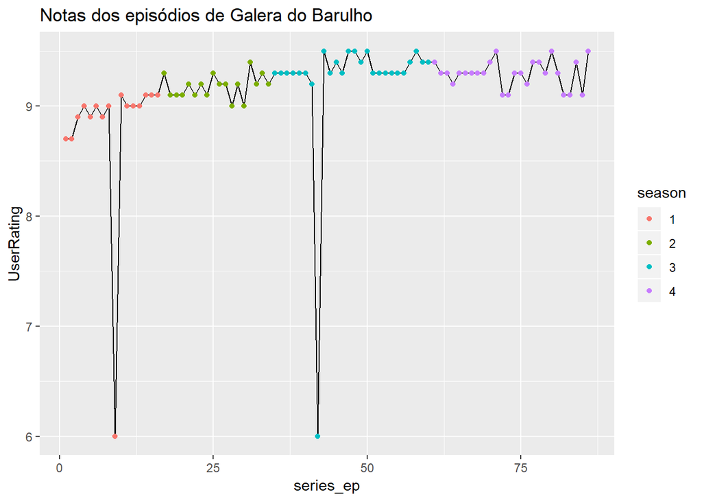

```r
top5 %>% filter(series_name == "Galera do Barulho") %>% ggplot() + geom_line(mapping = aes(x = series_ep, y = UserRating)) + geom_point(mapping = aes(x = series_ep, y = UserRating, color = season)) + labs(title = "Notas dos episódios de Galera do Barulho")
```

Em Galera do Barulho, podemos observar que a série se manteve bem estável, com um leve crescimento nas avaliações. É importante observar que houveram dois episódios bem abaixo da média da série.

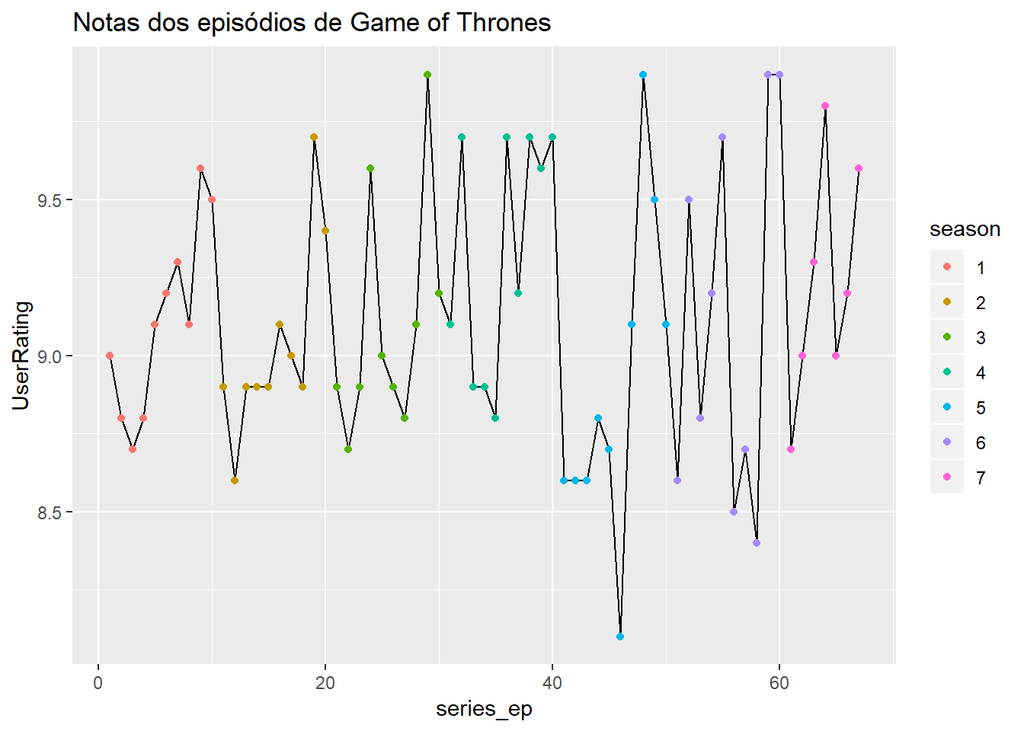

```r
top5 %>% filter(series_name == "Game of Thrones") %>% ggplot() + geom_line(mapping = aes(x = series_ep, y = UserRating)) + geom_point(mapping = aes(x = series_ep, y = UserRating, color = season)) + labs(title = "Notas dos episódios de Game of Thrones")
```

Em Game of Thrones, a variação das avaliações não nos permite identificar uma tendência, mas é possível identificar a diferença entre a pior avaliação com nota um pouco maior que 8 e as quatro maiores avaliações, que quase atingiram nota 10

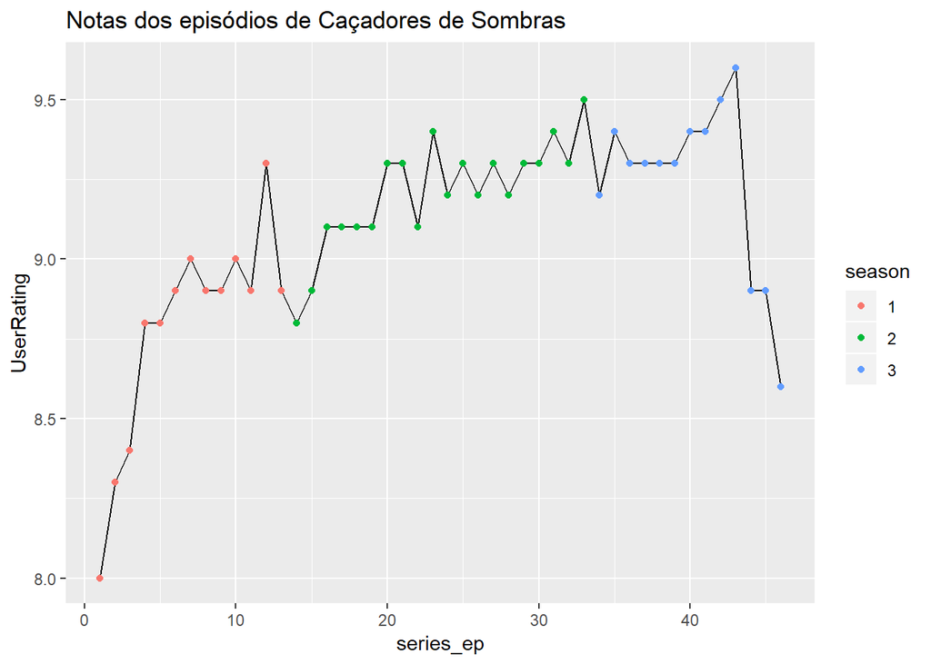

```r
top5 %>% filter(series_name == "Caçadores de Sombras") %>% ggplot() + geom_line(mapping = aes(x = series_ep, y = UserRating)) + geom_point(mapping = aes(x = series_ep, y = UserRating, color = season)) + labs(title = "Notas dos episódios de Caçadores de Sombras")
```

Em Caçadores de Sombras, é possível identificar um enorme avanço no decorrer da série, mas que na sua última temporada, obteve uma drástica queda.

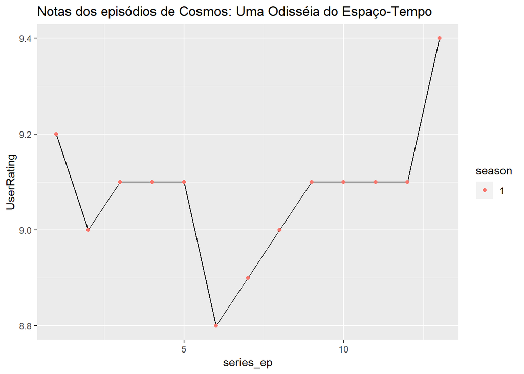

```r
top5 %>% filter(series_name == "Cosmos: Uma Odisséia do Espaço-Tempo") %>% ggplot() + geom_line(mapping = aes(x = series_ep, y = UserRating)) + geom_point(mapping = aes(x = series_ep, y = UserRating, color = season)) + labs(title = "Notas dos episódios de Cosmos: Uma Odisséia do Espaço-Tempo")
```

Em Cosmos: Uma Odisséia do Espaço-Tempo, é possível verificar que a série sofreu um declínio no meio da temporada, mas conseguiu se redimir e fechou seu episódio final com nota superior à do primeiro.

## Pergunta 3

**Há alguma relação entre as notas obtidas nos episódios e o numero de pessoas que os avaliaram?**

Tomando por exemplo a série Game of Thrones:

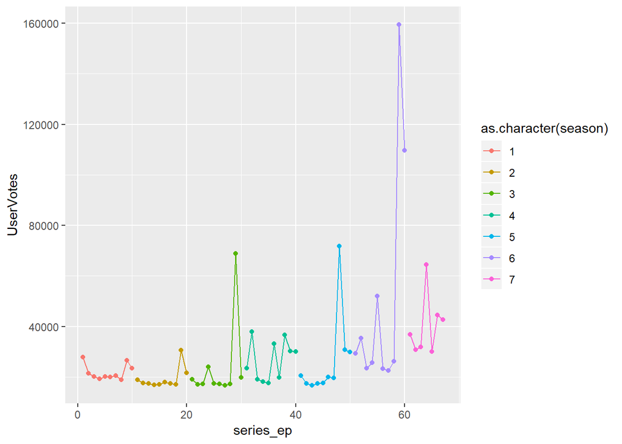

```r
top5 %>% filter(series_name == "Game of Thrones") %>% ggplot() + geom_line(mapping = aes(x = series_ep, y = UserVotes, color = as.character(season))) + geom_point(mapping = aes(x = series_ep, y = UserVotes, color = season))
```